# Project 1: Data Exploration and Visualization

Jenny Li, Xiang Li

2021/9/17

#Instruction

#Mian Section

> Visualtion one

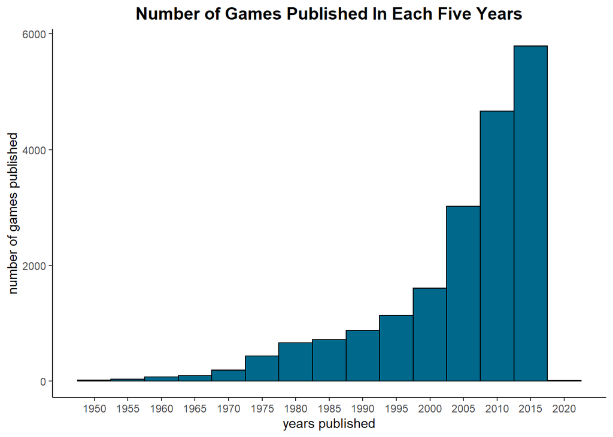

One of our assumptions of such circumstances is that it might be associated with the fast development of technology development. There will be more producers coming into this market and publishing more and more games as the technology develops in the following decades.

> Visualization two

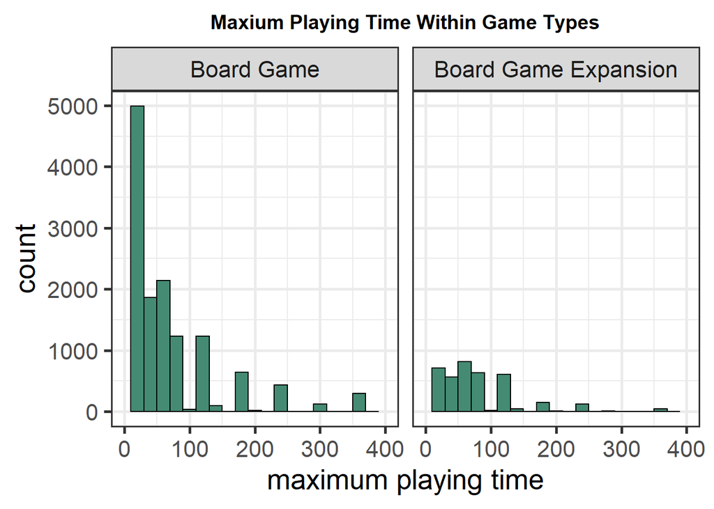

> Visualization three

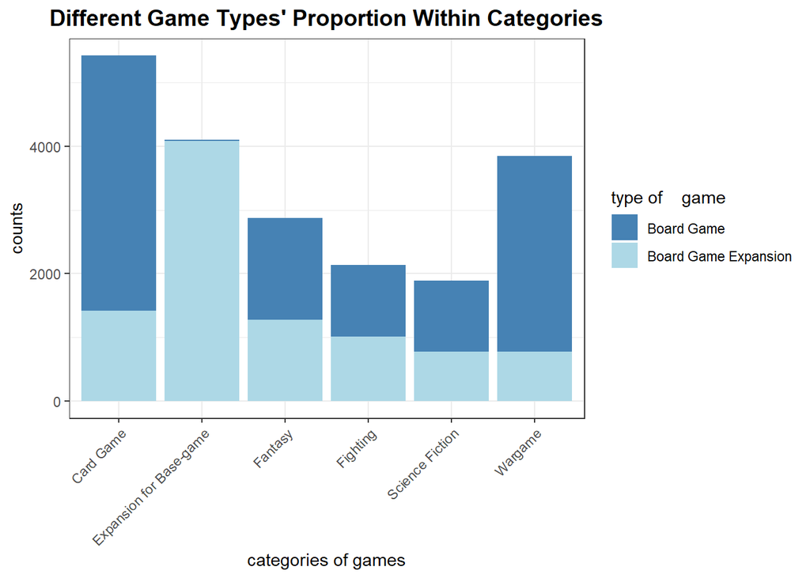

This stacked bar plot compares two types of board games in the first six categories that contain the most games. Since the expansion for base-game and board game expansion are similar, the light blue which represents the board game expansion takes over the category of expansion for base-game. For the other categories, the number of board games is much more than the board game expansion in Card Games and War games, and the number of board games is also slightly more in fantasy, fighting, and science fiction. According to visualization 2, board games are much more than board game expansion, which correlates in visualization 3 that we can see board game outweighs board game expansion in most of the categories, except for Expansion for Base-game.

We assume that maybe the game producers prefer to produce the board games since they might cost less or contain a higher profit. However, in some categories, the companies need to add new game areas, to create a better game experience, such as fantasy, fighting, and science fiction, which will be relatively evenly distributed into two types of game. In other categories of games, such as card games and war games, the necessity to combine with other elements is relatively low, with the number of board games being much more than the board game expansion.

> Visualization four

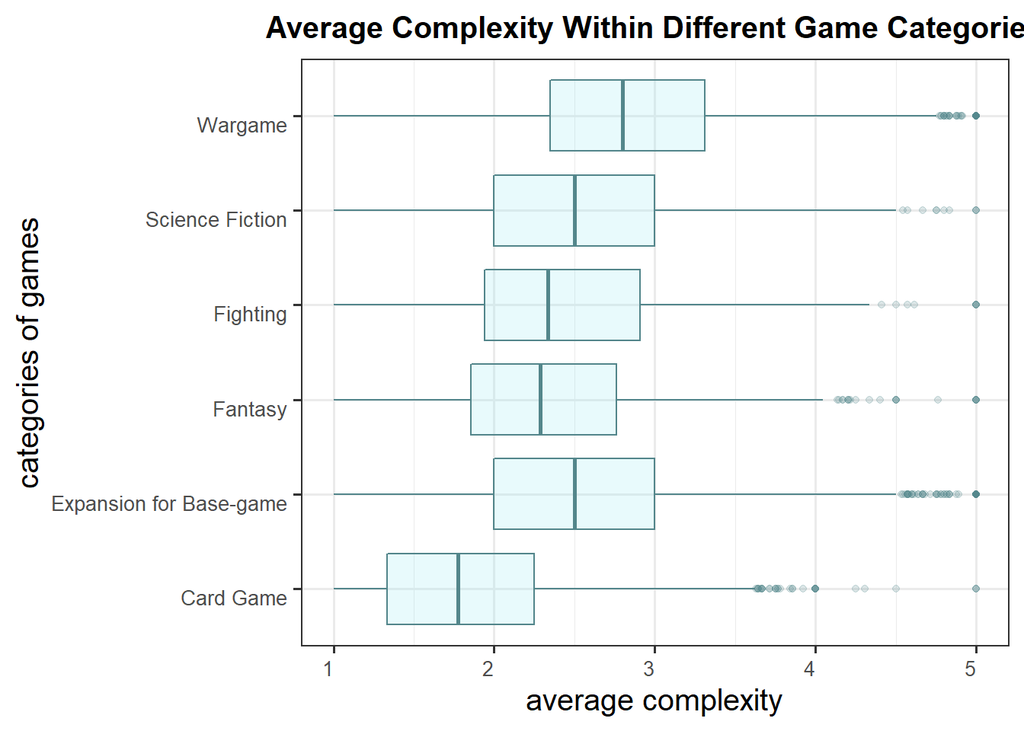

> Visualization five

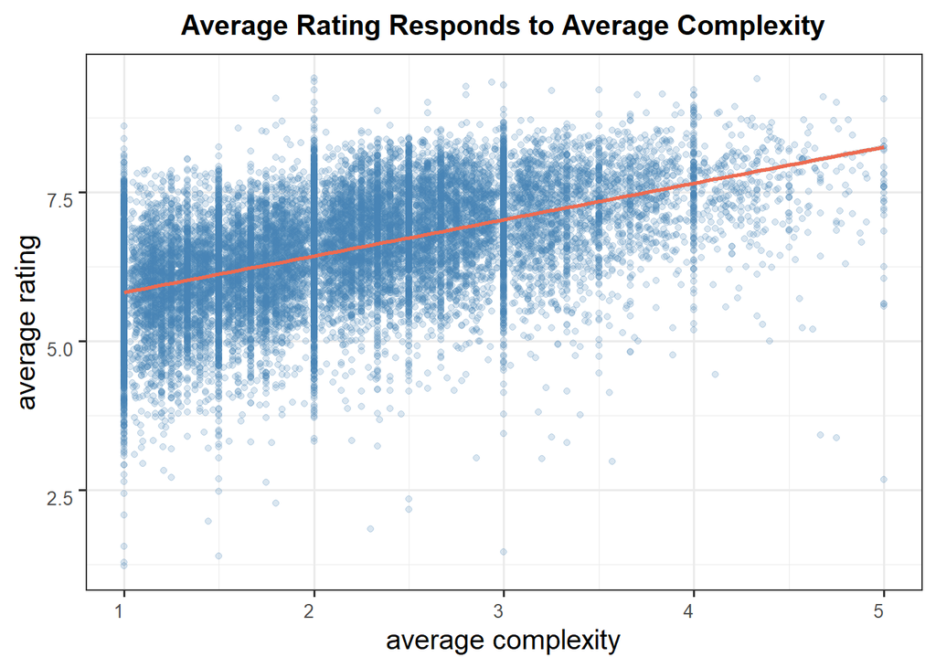

This scatterplot shows the relationship between the average rating and average complexity of these board games. They have a relatively moderate positive linear correlation (r = 0.5228426), but there are a few outliers. The average rating of the user towards the games is expected to find a positive difference in scores on average when comparing to the average complexity of the games that differs in scores by 1. When the average rating is between 5.0 and 7.5, more games are concentrating on average complexity between 1 and 4. When average complexity reaches 4 and 5, there are much fewer data points shown in the graph, inferring that there is much less rating for the games that have higher average complexity. So, we can also assume that there are fewer high complexity games.

> Viualization six

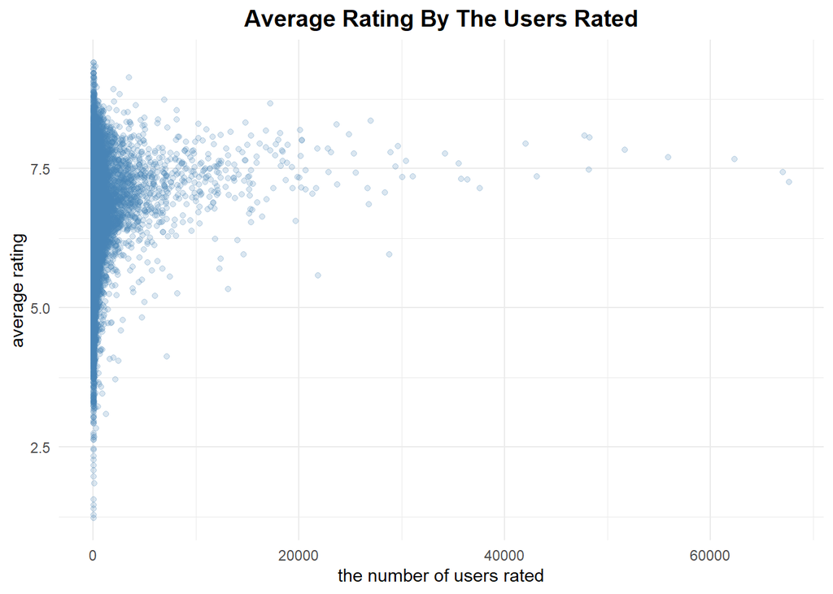

This scatterplot shows the relationship between the average rating and the number of users rated. Most users rated the game around the rating 7.5, which means the average rating and the number of users rated do not have a strong correlation. The rate of the games is mostly concentrated around 7.5, which indicates that the quality of the game is relatively even. There are more outliers around rating 7.5, and we can assume that more users rated the game, the game either be very popular, or it has been published for a very long time, or both.

> Conclusion

Visualization 1 is a left-skewed histogram that shows the number of games published within every five years.

Visualization 2 is a side by side histogram which shows the two types of game versus their maximum playing time. Also, it shows that one type of game is much more than the other one while the other has a relatively longer max playing time on average.

Visualization 3 compares two types of board games in the first six categories that contain the most games by stacked bar plots. In general, the number of board games is more than the board game expansion, except the expansion for base-game.

Visualization 5 shows the relationship between the board games’ average rating and average complexity by using a scatter plot. They have a relatively moderate positive linear correlation, although there are a few outliers.

Visualization 6 shows the relationship between the average rating and the number of users rated by using a scatter plot. Resulting in a relatively weak relationship between the two variables.

# Code Appendix

```r
library(tidyverse)
library(splitstackshape)

#filter games published in 1950 or later and with at least 25 ratings
newFull_gb<-full_bg%>%
  filter(yearpublished>=1950,users_rated>=25)

full_gbMechanic<-newFull_gb%>%
  cSplit("category", direction="wide")

full_gbCategory<-newFull_gb%>%
  cSplit("category", direction="long")

full_gbMechanic2<-newFull_gb%>%
  cSplit("mechanic", direction="wide")

#searching for certain category(contains the word in the name)
catan<-newFull_gb%>%
  filter(grepl("Catan",name))

#Mian Section

#Visualization one
#print(max(newFull_gb$yearpublished))

newFull_gb %>%
  ggplot(aes(x = yearpublished)) +
  labs(title = "Number of Games Published In Each Five Years",y ='number of games published', x = 'years published') +
  #change the interval into 5 years each
  scale_x_continuous(breaks = seq(1950, 2020, by = 5)) +
  geom_histogram(binwidth = 5,color = "black",fill="deepskyblue4") +
  theme_classic()+
  theme(plot.title = element_text (hjust = 0.5,
                                   face = "bold",
                                   size = 14))

#median(newFull_gb$yearpublished)

#Visualization Two
fac_lab = c(boardgame ="Board Game", boardgameexpansion="Board Game Expansion")

# filter the maxplaytime not equals to 0
newFull_gb0 <- newFull_gb %>%
  filter(maxplaytime != 0)

newFull_gb0 %>%
  ggplot(aes(x = maxplaytime)) +
  geom_histogram(binwidth = 20,  color = "black", fill = "aquamarine4", position = "identity") +
  theme_bw(base_size = 20) +
  labs(title = "Maxium Playing Time Within Game Types", x = 'maximum playing time') +
  xlim(0, 400) +
  facet_grid(. ~ game_type, labeller = labeller(game_type = fac_lab))+
  theme(plot.title = element_text (hjust = 0.5,
                                   face = "bold",
                                   size = 14))

# boardGame<-newFull_gb %>%
#   filter(game_type=='boardgame')
#
# median(boardGame$maxplaytime)
#
# boardGameExpansion<-newFull_gb %>%
#   filter(game_type=='boardgameexpansion')
#
# median(boardGameExpansion$maxplaytime)

#Visualization Three
# full_gbCategory %>%
#   count(game_type, category) %>%
#   group_by(category) %>%
#   mutate(relfreq = n / sum(n))

# full_gbCategory %>%
#   count(game_type, category) %>%
#   group_by(game_type) %>%
#   mutate(relfreq = n / sum(n))

category_choose <- full_gbCategory %>%
  filter(category %in% c("Card Game", "Expansion for Base-game", "Wargame", "Fantasy", "Fighting", "Science Fiction"))

category_choose %>%
  ggplot(aes(x = category, fill = game_type)) +
  geom_bar() +
  labs(title = "Different Game Types' Proportion Within Categories",x = 'categories of games', y = 'counts',
       fill = "type of    game") +
  scale_fill_manual(values = c("steelblue", "lightblue"),
                    labels = c("Board Game", "Board Game Expansion")) +
  theme_bw(base_size = 11) +
  theme(plot.title = element_text(hjust = 0.5, face = "bold", size = 14),
        axis.text.x = element_text(angle = 45, hjust = 1, vjust = 1))

#Visualization Four
#count how may games in each category
categoryCounts<-full_gbCategory %>%
  count(category)
#resorted it in the decreasing number of games in each category
newOrderCa <- categoryCounts[order(-n)]
#filter the first six category to create a new dataset
firstSixCa<-
  full_gbCategory %>% filter(category == "Card Game"|category == "Expansion for Base-game"|category == "Wargame"|category == "Fantasy"|category == "Fantasy"|category == "Fighting"|category == "Science Fiction")
firstSixCa_rm0 <- firstSixCa %>%
  filter(average_complexity != 0)

#boxplot
firstSixCa_rm0 %>%
  ggplot(aes(x=category, y=average_complexity)) + # categorical on x, quantitative on y
  geom_boxplot(color = 'cadetblue4',fill="cadetblue2",alpha=1/5) +
  coord_flip() +
  labs(title = "Average Complexity Within Different Game Categories", y = 'average complexity', x = 'categories of games') +
  theme_bw(base_size = 15) +
  theme(plot.title = element_text(hjust = 0.5,
                                  face = "bold",
                                  size = 15),
        axis.text = element_text(size=10),
        axis.text.x = element_text(hjust = 1, vjust = 1),
        axis.text.y = element_text(hjust = 1, vjust = 1))


#Visualization Five
newFull_gb1 <- newFull_gb %>%
  filter(average_complexity != 0)
newFull_gb1 %>%
  ggplot(aes(x = average_complexity , y = average_rating)) +
  geom_point(color = "steelblue", alpha = 0.2) +
  geom_smooth(method = 'lm',color='coral2')+
  labs(title = "Average Rating Responds to Average Complexity", x = "average complexity", y = "average rating") +
  theme_bw(base_size = 15) +
  theme(plot.title = element_text(hjust = 0.5,
                                  face = "bold",
                                  size = 20),
        axis.text = element_text(size = 10),
        axis.text.x = element_text(hjust = 1, vjust = 1),
        axis.text.y = element_text(hjust = 1, vjust = 1))
# cor(newFull_gb1$average_complexity, newFull_gb1$average_rating)

#Visualization Six
newFull_gb %>%
  ggplot(aes(x = users_rated, y = average_rating)) +
  labs(title = "Average Rating By The Users Rated", y = 'average rating', x = 'the number of users rated') +
  #take 5 points to complete a blue dot and add color to it
  geom_point(color = 'steelblue',alpha=1/5) +
  theme_minimal()+
  theme(plot.title = element_text(hjust = 0.5,
                                  face = "bold",
                                  size = 14))
```